# 共享单车的用户写照

## by Ivy

## 探索目的

> 了解共享单车的用户群体、主要用途和时间，为提供更有针对性的服务做准备。

## 数据集介绍

> 该数据集包含有关在旧金山湾区的自行车共享系统中的单次骑行信息。下载地址为：https://s3.amazonaws.com/baywheels-data/index.html 。本次分析只下载了 2018 年 1 - 12 月的数据。

## 用户类型分布

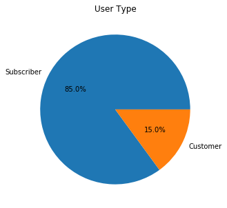

```python
df_copy.user_type.value_counts().plot(kind='pie', autopct='%.1f%%',figsize=(5,5))
plt.title('User Type')
plt.ylabel('');
```

## 会员与散客订单数量的差异：工作日还是周末？

> 会员的订单数远远大于散客的订单数，且在工作日时，会员的订单占比更大，会员更集中在工作日使用共享单车。

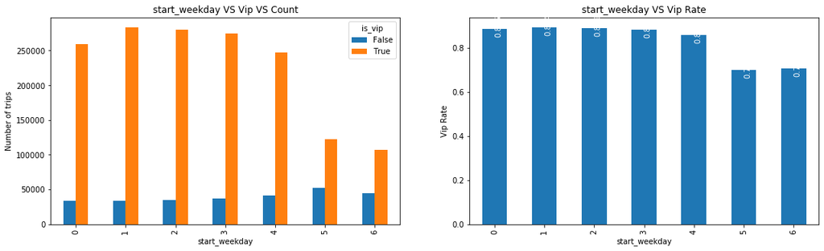

```python
variable_visulization(df_copy,'start_weekday')
```

## 会员与散客订单数量的差异：骑行开始小时？

> 会员的订单呈现两个峰值，集中在上下班高峰期，而非会员的骑行时间分布较为均匀，白天比晚上多。进一步说明会员的骑行用途更多是通勤。

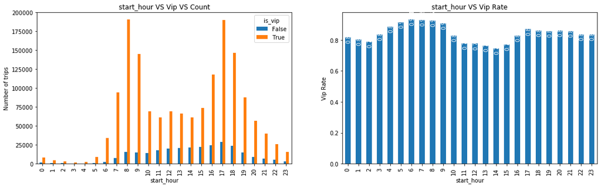

```python
variable_visulization(df_copy,'start_hour')
```

## 会员 vs 骑行时长

图中可以看到：

- 会员的骑行时长更集中，主要集中在 5-20 分钟；
- 散客的骑行时长比较分散且更为均匀，峰值的坡度比较缓和。

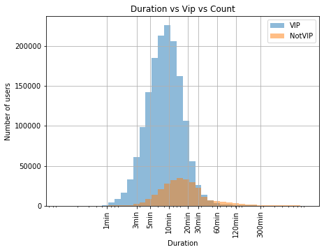

```python
duration_hist(df_copy[df_copy['is_vip']==True],'VIP')
duration_hist(df_copy[df_copy['is_vip']==False],'NotVIP')
```

## 会员 vs 骑行时长 vs 骑行开始时间

图中可以看到：

- 夜晚和凌晨的误差条都比较长，说明数据较为分散，没有那么明确的规律；
- 左右两个子图对比，可以看出左侧的长条都相对较高，说明非会员的骑行时长比会员的骑行时长要更长；
- 右侧会员的数据中，除了凌晨的个别时间段，基本上都处于 1000 以下，且误差条非常短，说明骑行时长集中，且时长都较短；
- 除了凌晨的个别时间段，基本上所有的橙色长条都比蓝色长条要高，说明基本上周末都比工作日的骑行时长要长；

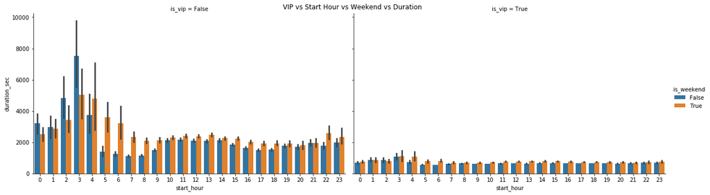

```python
g = sns.catplot(x="start_hour", y="duration_sec", hue="is_weekend", col="is_vip",
                data=df_copy, kind="bar", height=5, aspect=12/7)
g.fig.suptitle('VIP vs Start Hour vs Weekend vs Duration',fontsize=12);
```